# R/SSB and productivity changes

Author

Chris Legault and Charles Perretti

Published

September 9, 2025

```r
library(tibble)
library(tidyr)
library(dplyr)
library(ggplot2)
library(readr)
```

## BLUF

A time series of recruits per spawning stock biomass can only be used to detect changes in productivity in certain conditions. Care should be taken regarding expected trends in R/SSB as SSB changes before conclusions are reached regarding productivity changes.

## Productivity

There are many definitions of productivity, including the sum of recruitment, growth, and natural mortality (Prager (1994)), the ratio of outputs to inputs (Pan and Walden (2015)), the catch per unit area for a region (Stock et al. (2017)), or the slope of the stock-recruitment curve at the origin (Bell et al. (2023)). Surplus production models attempt to directly estimate the stock size that allows the largest catch to be taken on a continuing basis under the assumption that low stock sizes result in reduced reproduction while high stock sizes have density dependent impacts (Mildenberger et al. (2025)). Changes in stock productivity have been known for a long time (Beverton and Holt (1957), Walters (1987), Hilborn and Walters (1992)). Here, we define a change in productivity as a change in the stock-recruitment function over time. We examine whether the ratio of recruit abundance to spawning stock biomass (R/SSB) is a valid proxy for productivity. We will not directly address the use of covariates to try to explain changes in recruitment. Rather, we first explore some of the situations that can lead to expected changes in R/SSB and then address the common approach of examining a time series of R/SSB to determine which years to include in projected recruitment because the stock is thought to be in a new productivity regime.

## R/SSB basics

Recruits per spawning stock biomass values calculated here use the same method as used in typical stock-recruitment plots, where the recruits are one year later than the spawning stock biomass to reflect the outcome of reproduction. The R/SSB value for a given SSB-R combination on a stock recruitment plot is simply the slope of the line connecting the origin with the point. All points on the line have the same R/SSB and would therefore be assigned the same productivity. A simple example is shown below where four SSB-R points (A, B, C, D) have three different R/SSB (Figure 1). The R/SSB for point A is the highest of the four, the R/SSB is equal for points B and C, and the R/SSB is lowest for point D. The dashed line is a stationary stock-recruitment curve which shows the expected amount of recruitment for each SSB.

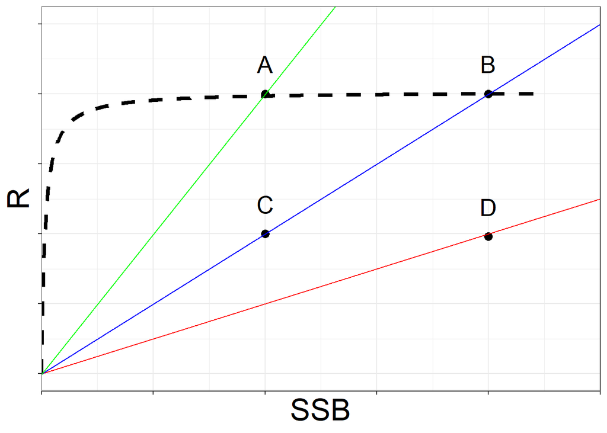

Figure 1: Spawning stock biomass (SSB) and recruitment (R) points (labelled A-D) and associated R/SSB lines that intersect at the origin along with an expected stock-recruitment relationship shown as a thick, dashed line.

```r
df <- tibble(SSB = c(1, 1, 2, 2),
             R = c(1, 2, 0.98, 2),
             labs = c("C", "A", "D", "B"))

R0 <- 2.0
steep <- 0.97
S0 <- 2
alpha <- 4 * steep * R0 / (5 * steep - 1)
beta <- S0 * (1 - steep) / (5 * steep - 1)
ssb <- seq(0, 2.25, length.out=1000)
recruits <- alpha * ssb / (beta + ssb)
dfsr <- tibble(SSB = ssb, R=recruits)

ggplot(df, aes(x=SSB, y=R)) +
  geom_point(cex=3) +
  geom_text(aes(label=labs), vjust = 0, nudge_y = 0.15, size=7) +
  geom_line(data=dfsr, aes(x=SSB, y=R), linetype=2, size=1.5) +
  #xlim(0, 2.5) +
  scale_x_continuous(limits = c(0, 2.5), expand = c(0, 0)) +
  ylim(0, 2.5) +
  geom_abline(intercept = 0, slope = 0.5, col="red") +
  geom_abline(intercept = 0, slope = 1, col="blue") +
  geom_abline(intercept = 0, slope = 2, col="green") +
  theme_bw() +
  theme(text = element_text(size=rel(5)),
        axis.text.x=element_blank(),
        axis.text.y=element_blank()
  )
```

If we continue to define a change in productivity as a change in the stock-recruitment relationship, we can see in the figure above that R/SSB does reflect a difference in productivity when SSB is held constant. For example, point A has higher R/SSB and higher productivity than point C. However, when SSB differs, R/SSB may not reflect the correct change in the productivity. In the figure above, the stock-recruitment curve passes through points A and B. There is no change in the dashed stock-recruitment curve as it moves from A to B, however there is a change in R/SSB. This lack of relationship can be seen more generally by examining all the values of R and R/SSB for a range of SSB (Figure 2). When the Beverton-Holt stock-recruitment relationship (Beverton and Holt (1957)) is followed exactly, the associated R/SSB has a strong increase as SSB decreases from the unfished population to the origin. In contrast, a constant R/SSB is associated with a straight line on the stock-recruitment plot, as noted above, meaning there is no density dependence in recruitment with increasing SSB, something that is biologically impossible across the full range of SSB for the stock as it would imply an infinite or zero population in equilibrium. A constant recruitment stock-recruitment relationship is hyperbolic when plotted as R/SSB versus SSB (values of R/SSB go to infinity as SSB goes to zero).

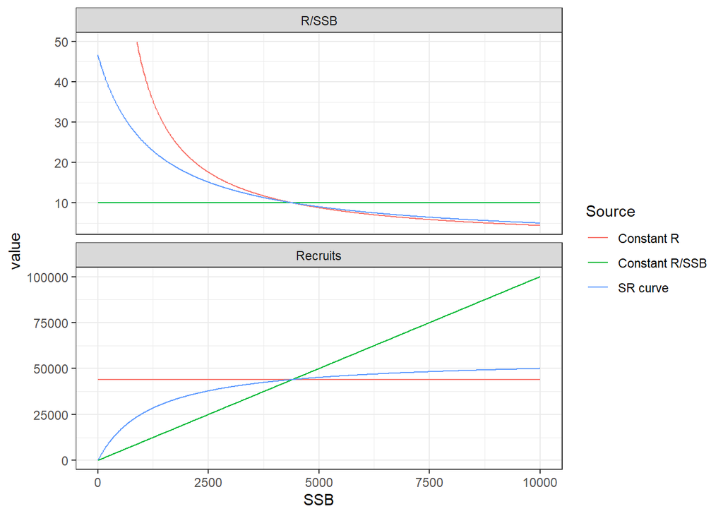

Figure 2: Recruits and recruits per spawning stock biomass (R/SSB) as a function of SSB. Three lines are shown in each panel. One is for a Beverton-Holt stock-recruitment curve (denoted SR curve), one shows a constant R/SSB, and the final shows a constant recruitment.

```r
S0 <- 10000
R0 <- 50000
spr0 <- S0/R0
steep <- 0.7
alpha <- 4 * steep * R0 / (S0 * (1 - steep))
beta <- (alpha * spr0 - 1) / S0

ssb <- seq(1, S0, length.out = 1000)
recruits <- alpha * ssb / (1 + beta * ssb)

srcurve <- tibble(Source="SR curve", SSB=ssb, Recruits=recruits)
constantrperssb <- tibble(Source="Constant R/SSB", SSB=ssb, Recruits=10 * ssb)
constr <- tibble(Source="Constant R", SSB=ssb, Recruits=44000)

mydat <- rbind(srcurve, constantrperssb, constr) |>
  mutate("R/SSB"=ifelse(Recruits/SSB > 50, NA, Recruits/SSB)) |>
  pivot_longer(cols = c(Recruits, "R/SSB"), names_to = "Response", values_to = "value")

ggplot(mydat, aes(x=SSB, y=value, color=Source)) +
  geom_line() +
  facet_wrap(~Response, scales="free_y", ncol=1) +
  theme_bw()
```

## Controlling, Masking, and Limiting Factors

In the Woods Hole Assessment Model (WHAM, Stock and Miller (2021)), there are multiple options to have the stock-recruitment relationship modified by an environmental covariate which follows the terminology of Fry (1971) and Iles and Beverton (1998). When all three $\theta$ parameters are zero, Equation 1 is the standard Beverton-Holt stock-recruitment relationship. The three options for modification set one of the $\theta$ values to a non-zero value and while the other two $\theta$ values are set to zero: controlling $\theta_1$, masking $\theta_2$, and limiting $\theta_3$, respectively for the non-zero $\theta$ values. The X in Equation 1 denotes the environmental variable and can be year-specific. Each of the three modifications changes both the stock-recruitment relationship as well as the R/SSB vs SSB relationship (Figure 3). Each of these three factors could be considered a change in productivity. As an aside, the controlling and masking factors change the steepness of the stock-recruitment relationship, while the limiting factor does not (Table 1).

$$R = \frac{\alpha ~ SSB ~ e^{\theta_1 X}}{e^{\theta_2 X} ~ + \beta ~ ~ SSB ~ e^{\theta_3 X}}
\tag{1}$$

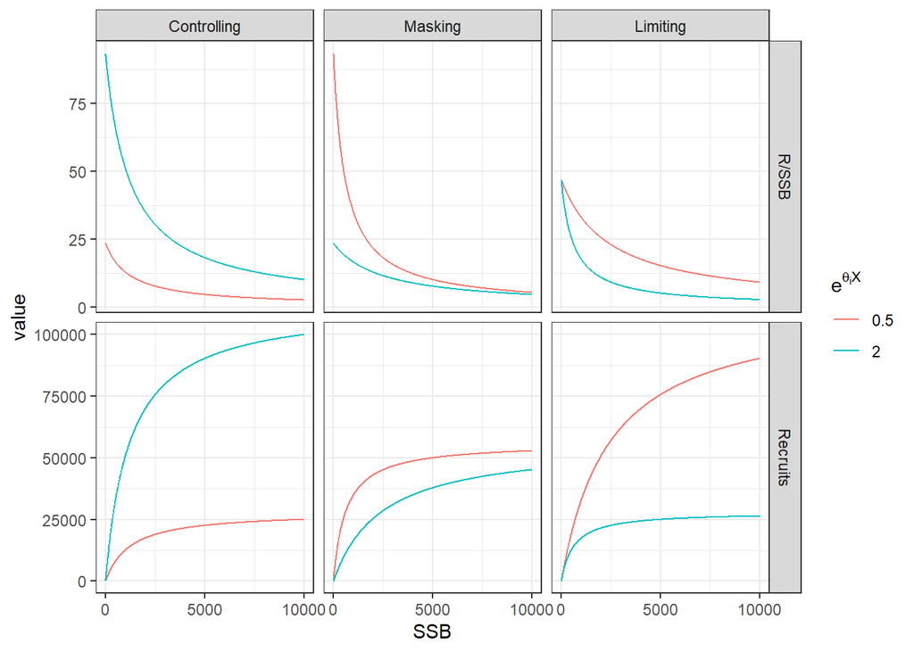

Figure 3: Recruits and recruits per spawning stock biomass (R/SSB) as a function of SSB for the three modifications to the standard Beverton-Holt equation - controlling, masking, and limiting. The theta and X values are selected to result in the non-zero $\theta$ term $e^{\theta_i X}$ in Equation 1 equalling 0.5 or 2. The SSB range is the same as in Figure 2, which shows the base model when none of the three factors apply (all three $\theta$ are zero).

```r
control_thetas <- c(1, 0, 0)
mask_thetas <- c(0, 1, 0)
limit_thetas <- c(0, 0, 1)

apply_thetas <- function(thetas, X, alpha, beta, ssb){
  recruits <- alpha * ssb * exp(thetas[1]*X) / (exp(thetas[2]*X) + beta * ssb * exp(thetas[3]*X))
  return(recruits)
}

Rc1 <- tibble(Factor="Controlling", X=0.5, SSB=ssb,
              Recruits=apply_thetas(control_thetas, log(0.5), alpha, beta, ssb))
Rc2 <- tibble(Factor="Controlling", X=2, SSB=ssb,
              Recruits=apply_thetas(control_thetas, log(2.0), alpha, beta, ssb))
Rm1 <- tibble(Factor="Masking", X=0.5, SSB=ssb,
              Recruits=apply_thetas(mask_thetas, log(0.5), alpha, beta, ssb))
Rm2 <- tibble(Factor="Masking", X=2, SSB=ssb,
              Recruits=apply_thetas(mask_thetas, log(2.0), alpha, beta, ssb))
Rl1 <- tibble(Factor="Limiting", X=0.5, SSB=ssb,
              Recruits=apply_thetas(limit_thetas, log(0.5), alpha, beta, ssb))
Rl2 <- tibble(Factor="Limiting", X=2, SSB=ssb,
              Recruits=apply_thetas(limit_thetas, log(2.0), alpha, beta, ssb))
cmldf <- rbind(Rc1, Rc2, Rm1, Rm2, Rl1, Rl2) |>
  mutate(Factor = factor(Factor, levels = c("Controlling", "Masking", "Limiting"))) |>
  mutate("R/SSB"=Recruits/SSB) |>
  pivot_longer(cols = c(Recruits, "R/SSB"), names_to = "Response", values_to = "value")

ggplot(cmldf, aes(x=SSB, y=value, color=as.factor(X))) +
  geom_line() +
  facet_grid(Response~Factor, scales="free_y") +
  labs(color = expression(e^{theta[i] * X})) +
  scale_x_continuous(breaks=c(0, 5000, 10000)) +
  theme_bw()
```

```r
calc_steepness <- function(thetas, X, alpha, beta, spr0, runname){
  cval <- exp(thetas * X)
  SSB0 <- (alpha * spr0 * cval[1] - cval[2]) / (beta * cval[3])
  R0 <- apply_thetas(thetas, X, alpha, beta, SSB0)
  steep <- round(apply_thetas(thetas, X, alpha, beta, 0.2 * SSB0) / R0, 3)
  res <- tibble(Case = runname, Val1 = cval[1], Val2 = cval[2], Val3 = cval[3], Steepness = steep)
  return(res)
}

base_steep <- calc_steepness(c(0,0,0), 1, alpha, beta, spr0, "Base")
control05_steep <- calc_steepness(control_thetas, log(0.5), alpha, beta, spr0, "Controlling")
control2_steep <- calc_steepness(control_thetas, log(2.0), alpha, beta, spr0, "Controlling")
mask05_steep <- calc_steepness(mask_thetas, log(0.5), alpha, beta, spr0, "Masking")
mask2_steep <- calc_steepness(mask_thetas, log(2.0), alpha, beta, spr0, "Masking")
limit05_steep <- calc_steepness(limit_thetas, log(0.5), alpha, beta, spr0, "Limiting")
limit2_steep <- calc_steepness(limit_thetas, log(2.0), alpha, beta, spr0, "Limiting")
steepdf <- rbind(base_steep, control05_steep, control2_steep, mask05_steep, mask2_steep, limit05_steep, limit2_steep)

knitr::kable(steepdf)
```

Table 1: Steepness for the base, controlling, masking, and limiting stock-recruitment relationships shown in Figures 2-3, where Vali indicates the value of $e^{\theta_i X}$.

| Case | Val1 | Val2 | Val3 | Steepness |
| --- | --- | --- | --- | --- |
| Base | 1.0 | 1.0 | 1.0 | 0.700 |
| Controlling | 0.5 | 1.0 | 1.0 | 0.538 |
| Controlling | 2.0 | 1.0 | 1.0 | 0.824 |
| Masking | 1.0 | 0.5 | 1.0 | 0.824 |
| Masking | 1.0 | 2.0 | 1.0 | 0.538 |
| Limiting | 1.0 | 1.0 | 0.5 | 0.700 |
| Limiting | 1.0 | 1.0 | 2.0 | 0.700 |

## Depensation

Depensation is defined as a reduction in expected recruitment relative to the stock-recruitment curve as spawning stock biomass approaches zero. There are many ways this can be modeled. Here a function is used to connect the origin with a breakpoint in the standard stock-recruitment relationship using a power function defined by the parameter $\beta_d$ in Equation 2.

$$R = \alpha_d SSB ^ {\beta_d}
\tag{2}$$

when SSB is below the breakpoint. For a given value of $\beta_d$, $\alpha_d$ can be solved as recruitment at the breakpoint divided by the SSB breakpoint raised to the power $\beta_d$. In Figure 4, three values of $\beta_d$ are shown for the case where the SSB breakpoint is set at one fifth of the unexploited spawning stock biomass (0.2 $SSB_0$). When $\beta_d$ is one, the stock-recruitment points form a straight line between the origin and the breakpoint, resulting in a constant value of R/SSB for these SSB values. Increasing $\beta_d$ values greater than one cause the recruits to drop more for SSB below the breakpoint and result in lines connecting the origin and the breakpoint for R/SSB. Similarly, R/SSB and recruits change when the breakpoint changes (Figure 5).

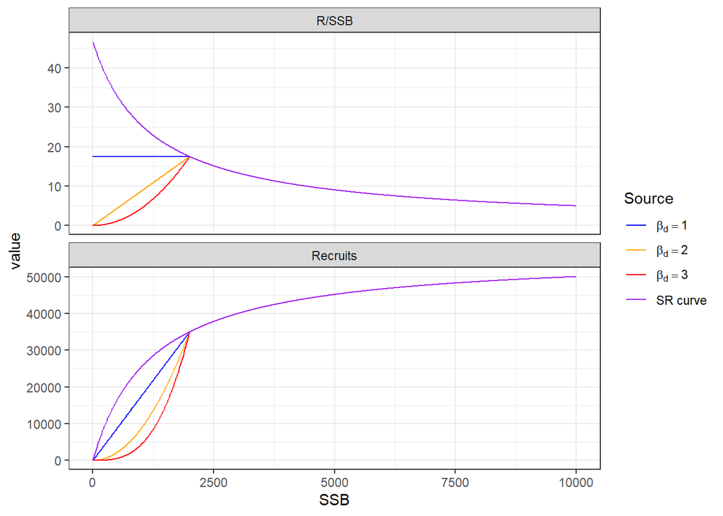

Figure 4: Recruits and recruits per spawning stock biomass (R/SSB) as a function of SSB for the standard stock-recruitment curve along with three types of depensation, defined by the parameter $\beta_d$, when the breakpoint is set at 0.2 of $SSB_0$.

```r
calc_sr_depensation <- function(alpha, beta, ssb_breakpoint, depen_beta, ssb){
  r_breakpoint <- alpha * ssb_breakpoint / (1 + beta * ssb_breakpoint)
  depen_alpha <- r_breakpoint / (ssb_breakpoint^depen_beta)
  recruits_depen <- ifelse(ssb <= ssb_breakpoint, depen_alpha*ssb^depen_beta, alpha * ssb / (1 + beta * ssb))
  return(recruits_depen)
}

ssb_breakpoint <- 0.2 * S0
recruits_depen_1 <- calc_sr_depensation(alpha, beta, ssb_breakpoint, depen_beta = 1, ssb)
recruits_depen_2 <- calc_sr_depensation(alpha, beta, ssb_breakpoint, depen_beta = 2, ssb)
recruits_depen_3 <- calc_sr_depensation(alpha, beta, ssb_breakpoint, depen_beta = 3, ssb)

mydat1 <- tibble(Source="beta_d=1", SSB = ssb, Recruits=recruits_depen_1)
mydat2 <- tibble(Source="beta_d=2", SSB = ssb, Recruits=recruits_depen_2)
mydat3 <- tibble(Source="beta_d=3", SSB = ssb, Recruits=recruits_depen_3)
mydatc <- rbind(srcurve, mydat1, mydat2, mydat3) |>
  mutate("R/SSB"=Recruits/SSB) |>
  pivot_longer(cols = c(Recruits, "R/SSB"), names_to = "Response", values_to = "value")

ggplot(mydatc, aes(x=SSB, y=value, color=Source)) +
  geom_line() +
  facet_wrap(~Response, scales="free_y", ncol=1) +
  scale_color_manual(values = c("blue", "orange", "red", "purple"),
                     breaks = c("beta_d=1", "beta_d=2", "beta_d=3", "SR curve"),
                     labels = c(expression(beta[d]==1),
                                expression(beta[d]==2),
                                expression(beta[d]==3),
                                "SR curve")) +
  theme_bw()
```

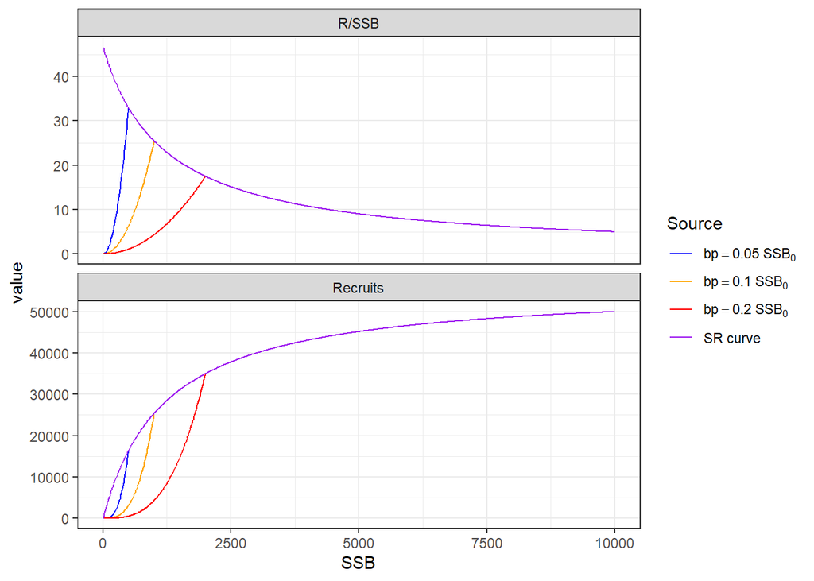

Figure 5: Recruits and recruits per spawning stock biomass (R/SSB) as a function of SSB for the standard stock-recruitment curve along with three types of depensation, defined by the parameter breakpoints (bp) at 0.05, 0.1, and 0.2 of $SSB_0$, when $\beta_d$ is set to 3.

```r
recruits_depen_4 <- calc_sr_depensation(alpha, beta, ssb_breakpoint=0.05*S0, depen_beta = 3, ssb)
recruits_depen_5 <- calc_sr_depensation(alpha, beta, ssb_breakpoint=0.1*S0, depen_beta = 3, ssb)
recruits_depen_6 <- calc_sr_depensation(alpha, beta, ssb_breakpoint=0.2*S0, depen_beta = 3, ssb)
mydat4 <- tibble(Source="bp005SSB0", SSB = ssb, Recruits=recruits_depen_4)
mydat5 <- tibble(Source="bp01SSB0", SSB = ssb, Recruits=recruits_depen_5)
mydat6 <- tibble(Source="bp02SSB0", SSB = ssb, Recruits=recruits_depen_6)
mydatd <- rbind(srcurve, mydat4, mydat5, mydat6) |>
  mutate("R/SSB"=Recruits/SSB) |>
  pivot_longer(cols = c(Recruits, "R/SSB"), names_to = "Response", values_to = "value")

ggplot(mydatd, aes(x=SSB, y=value, color=Source)) +
  geom_line() +
  facet_wrap(~Response, scales="free_y", ncol=1) +
  scale_color_manual(values = c("blue", "orange", "red", "purple"),
                     breaks = c("bp005SSB0", "bp01SSB0", "bp02SSB0", "SR curve"),
                     labels = c(expression(bp==0.05~SSB[0]),
                                expression(bp==0.1~SSB[0]),
                                expression(bp==0.2~SSB[0]),
                                "SR curve")) +
  theme_bw()
```

## Slight detour

Since R/SSB is a ratio, the value can change with either changes in the numerator or the denominator. Many stock assessment models end up treating SSB as an after-the-fact calculation because there is not a relationship between recruitment and SSB (or it is effectively an after-the-fact calculation because the noise around the relationship is so large that it is essentially not changing the recruitment estimate). In this case, changes in the weights at age, maturity, or timing within the year of spawning can all create changes in SSB that do not impact the overall fit of the model, or importantly for this analysis, the recruitment estimates. An increase in weights at age would typically be perceived as positive event for the stock. However, since SSB is in the denominator of R/SSB, the R/SSB value will decrease with an increase in weights at age, therefore perceived productivity would decrease.

In the remainder of this paper, weights at age, maturity, and natural mortality will all be held constant. This allows the use of the R0 and steepness formulation for defining stock-recruitment curves because there is no concern with the meaning of steepness changing over time (Miller and Brooks (2021)).

## Linearized Ricker

The Ricker stock-recruitment relationship (Equation 3)

$$R = \alpha S e^{-\beta S}
\tag{3}$$

is commonly used in salmon studies where additional spawners (S, in numbers of individuals) can destroy the eggs laid by previous spawners (Ricker (1954)). This equation is also sometimes used for marine species replacing S with SSB, where its theoretical basis is less well understood. A benefit of this equation is that it can be linearized on natural log scale (Equation 4)

$$ln(R/S) = ln(\alpha) - \beta S.
\tag{4}$$

## When can R/SSB indicate changes in productivity?

R/SSB decreasing when SSB decreases over a wide range might indicate a decrease in productivity because the expectation from the stock-recruitment relationship is that R/SSB should increase in this situation. Similarly, R/SSB increasing when SSB increases over a wide range might indicate an increase in productivity because the expectation from the stock-recruitment relationship is the R/SSB should decrease in this situation. However, defining a wide range for a specific example can be challenging, and the usual variability in recruitment about a stock-recruitment relationship may artificially create what appears to be a sufficiently wide range of SSB. Any depensation at low SSB can also make interpretation of changes, or lack thereof, in R/SSB challenging. Distinguishing among any of these situations is more difficult the greater the annual deviations from the underlying stock-recruitment relationship (typically denoted $\sigma_R$ in modeling contexts). The use of numbers at age transition random effects in a state-space model such as WHAM can also make interpretation of cohort strength from the recruitment time series challenging.

## Time series

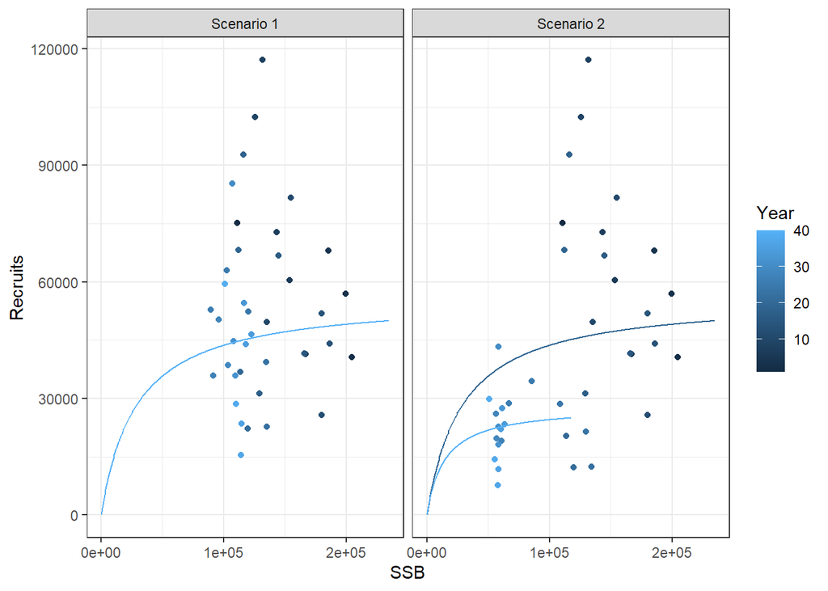

Figure 6: Annual recruits and spawning stock biomass (SSB) shown as points with the underlying stock-recruitment relationship shown by lines. In scenario 2, the R0 value is reduced by half during the second half of the time series. The same recruitment deviations are used in both scenarios.

```r
# function to calculate equilibrium population at age
calc_Nequilibrium <- function(nages, M, Fval, selx){
  age <- 1:nages
  Z <- M + Fval * selx
  N <- rep(1, nages)
  for (ia in 1:(nages-1)){
    N[ia+1] <- N[ia] * exp(-Z[ia])
  }
  N[nages] <- N[nages] / (1 - exp(-Z[nages]))
  return(N)
}

# function to calculate equilibrium spawning stock biomass per recruit
calc_spr <- function(nages, M, Fval, selx, waa, maturity){
  age <- 1:nages
  Z <- M + Fval * selx
  N <- rep(1, nages)
  for (ia in 1:(nages-1)){
    N[ia+1] <- N[ia] * exp(-Z[ia])
  }
  N[nages] <- N[nages] / (1 - exp(-Z[nages]))
  spr <- sum(N * waa * maturity)
  return(spr)
}

# converts productivity regime R0, steepness formulations to time series of alpha, beta SR curves
# R = alpha * SSB / (beta + SSB)
# note: assumes M, waa, and maturity do not change over time
convert_regimes_to_ts <- function(nyears, nproductivity, yearstarts, R0s, steepnesses, sigmaRs, spr0){

  year <- 1:nyears
  sralphas <- rep(NA, nyears)
  srbetas <- rep(NA, nyears)
  srsigmaRs <- rep(NA, nyears)

  for (ip in 1:nproductivity){
    sralphas[yearstarts[ip]:nyears] <- 4 * steepnesses[ip] * R0s[ip] / (5 * steepnesses[ip] - 1)
    srbetas[yearstarts[ip]:nyears] <- spr0 * R0s[ip] * (1 - steepnesses[ip]) / (5 * steepnesses[ip] - 1)
    srsigmaRs[yearstarts[ip]:nyears] <- sigmaRs[ip]
  }
  sr <- list(sralphas=sralphas, srbetas=srbetas, srsigmaRs=srsigmaRs)
  return(sr)
}

# calculate annual stock-recruitment curves from sr object
calc_sr_curves <- function(sr, mylabel){
  nyears <- length(sr$SSB0)
  for (iy in 1:nyears){
    myssb <- seq(0, sr$SSB0[iy], length.out=500)
    myr <- sr$sralphas[iy] * myssb / (sr$srbetas[iy] + myssb)
    thisdf <- tibble(TS = mylabel,
                     Year = iy,
                     SSB = myssb,
                     Recruits = myr)
    if (iy == 1){
      srdf <- thisdf
    }
    else{
      srdf <- rbind(srdf, thisdf)
    }

  }
  return(srdf)
}

# function to create a time series of SSB and R for use in R/SSB analysis
# user controls the time series length and F as well as how many productivity periods there are
# yearstarts, R0s, steepnesses, and sigmaRs are vectors of length nproductivity
# that define the SR curve during that period, note the first value in yearstarts should always be 1
# user cannot control number of ages, weight at age, maturity, or M
make_ts <- function(nyears, Fmult, nproductivity, yearstarts, R0s, steepnesses, sigmaRs){

  if (yearstarts[1] != 1) return("First value in yearstarts vector must be 1")

  nages <- 10
  age <- 1:nages
  M <- 0.3
  selx <- round(1 - 1 / (1 + exp(1.2*(age - 3))), 3)
  maturity <- round(1 - 1 / (1 + exp(2*(age - 2.75))), 3)
  waa <- round(5 * (1 - exp(-0.3*(age-0.2)))^3, 3)

  # get equilibrium spawners per recruit at F=0
  spr0 <- calc_spr(nages, M, Fval=0, selx, waa, maturity)

  # get SR curves time series
  sr <- convert_regimes_to_ts(nyears, nproductivity, yearstarts, R0s, steepnesses, sigmaRs, spr0)
  sr$SSB0 <- sr$sralphas * spr0 - sr$srbetas

  # calculate spr in year 1 and find equilibrium SSB
  spr1 <- calc_spr(nages, M, Fval=Fmult[1], selx, waa, maturity)
  SSB1 <- sr$sralphas[1] * spr1 - sr$srbetas[1]

  # create N in first year using random recruitment about expected value from SSB1 (equilibrium-ish)
  # for plus group, use expected recruitment
  R1expected <- sr$sralphas[1] * SSB1 / (sr$srbetas[1] + SSB1)
  R1rand <- R1expected * exp(rnorm(nages-1, 0, sr$srsigmaRs[1]))
  N1 <- calc_Nequilibrium(nages, M, Fval=Fmult[1], selx)
  NAA <- matrix(NA, nrow=nyears, ncol=nages)
  NAA[1, ] <- c(R1rand, R1expected) * N1

  # fill out NAA matrix and collect SSB
  ssb <- rep(NA, nyears)
  ssb[1] <- SSB1
  for (iy in 1:(nyears-1)){
    # apply correct SR curve and noise to get Recruitment
    NAA[iy+1, 1] <- (sr$sralphas[iy] * ssb[iy] / (sr$srbetas[iy] + ssb[iy])) * exp(rnorm(1, 0, sr$srsigmaRs[iy]))
    for (ia in 1:(nages-1)){
      Z <- M + Fmult[iy] * selx[ia]
      NAA[iy+1, ia+1] <- NAA[iy, ia] * exp(-Z)
    }
    Z <- M + Fmult[iy] * selx[nages]
    NAA[iy+1, nages] <- NAA[iy, nages] * exp(-Z)
    ssb[iy+1] <- sum(NAA[iy+1, ] * waa * maturity)
  }

  res <- list(ssb=ssb[1:(nyears-1)], recruits=NAA[2:nyears, 1], sr=sr)
  return(res)
}

ny <- 40
Fmult <- rep(0.2, ny)
set.seed(14)
ts1 <- make_ts(ny, Fmult, 1, 1, 50000, 0.7, 0.5)
set.seed(14)
ts2 <- make_ts(ny, Fmult, 2, c(1, 20), c(50000, 25000), c(0.7, 0.7), c(0.5, 0.5))
tsdf <- tibble(TS = rep(c("Scenario 1", "Scenario 2"), each=(ny-1)),
               Year = rep(1:(ny-1), 2),
               SSB = c(ts1$ssb, ts2$ssb),
               Recruits = c(ts1$recruits, ts2$recruits)) |>
  mutate(RpSSB = Recruits/SSB)


sr1 <- calc_sr_curves(ts1$sr, "Scenario 1")
sr2 <- calc_sr_curves(ts2$sr, "Scenario 2")
sr12 <- rbind(sr1, sr2)

ggplot(tsdf, aes(x=SSB, y=Recruits, color=Year, group = Year)) +
  geom_point() +
  geom_line(data=sr12) +
  facet_wrap(~TS) +
  xlim(0, NA) +
  ylim(0, NA) +
  scale_x_continuous(breaks = c(0, 100000, 200000)) +
  theme_bw()
```

As seen in Figure 6, when productivity (meaning the stock-recruitment curve in this case) decreases during the second half of the time period, the recruitment drops which then leads to lower SSB, which then leads to lower recruitment. For these two scenarios, the same random number seed was used to generate the recruitment deviations, and the $\sigma_R$ was held constant at 0.5 across all years and scenarios. Note that both SR curves are plotted through their respective SSB0 values, which form a straight line with the origin because they have the same unexploited spawning stock biomass per recruit.

So can this change in productivity be seen in the time series of Recruits, SSB, or R/SSB? There is a short period of reduced R/SSB in the first few years after the sudden change from the higher to lower productivity, but then the R/SSB returns to values nearly identical to those from the first scenario for years 30-40, despite the large change in Recruits and SSB during this period (Figure 7). However, the R/SSB vs SSB plot does show a change between the two scenarios (Figure 8).

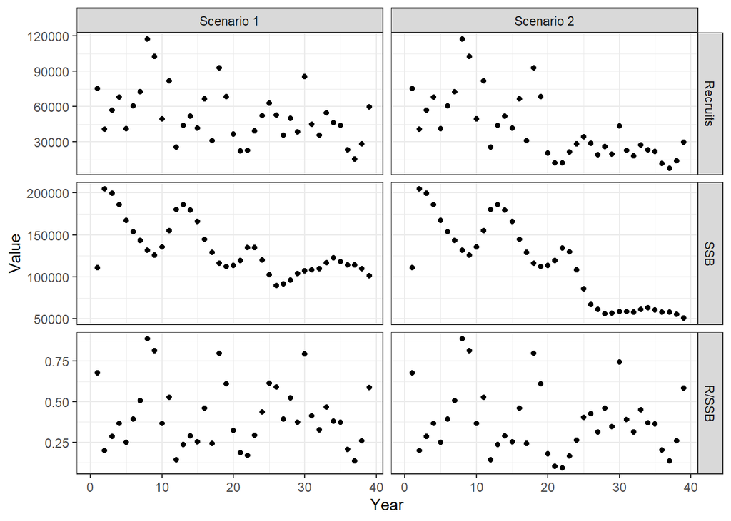

Figure 7: Annual values of recruits (R), spawning stock biomass (SSB), and R/SSB for the two scenarios defined in Figure 6.

```r
tsdflong <- tsdf |>
  rename("R/SSB" = RpSSB) |>
  pivot_longer(cols = !c(Year, TS), names_to = "Metric", values_to = "Value") |>
  mutate(Metric = factor(Metric, levels=c("Recruits", "SSB", "R/SSB")))

ggplot(tsdflong, aes(x=Year, y=Value)) +
  geom_point() +
  facet_grid(Metric~TS, scales="free_y") +
  xlim(0, NA) +
  theme_bw()
```

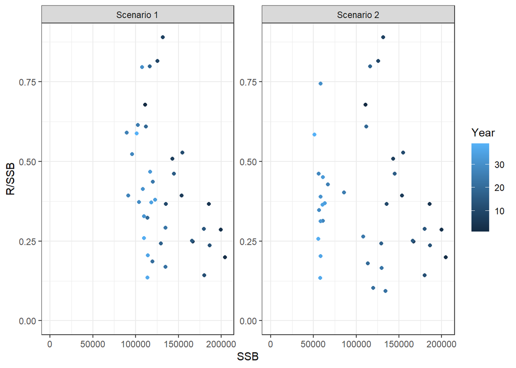

Figure 8: Recruits per spawning stock biomass (R/SSB) as a function of the spawning stock biomass (SSB) used in the ratio each year for the two scenarios defined in Figure 6.

```r
ggplot(tsdf, aes(x=SSB, y=RpSSB, color = Year)) +
  geom_point() +
  facet_wrap(~TS, scales="free_y") +
  xlim(0, NA) +
  ylim(0, NA) +
  ylab("R/SSB") +
  theme_bw()
```

## Change point analysis

Change point analyses have been demonstrated to perform poorly in terms of identifying actual changes in marine ecosystem time series (Haines et al. (2024)). Some commonly applied change point analyses include STARS (Rodionov (2004)), available in the *rshift* R package (Room et al. (2020)), and chronological clustering (Legendre and L. (2012)), available in the *rpart* R package (Therneau et al. (2015)). While change point analyses are intuitively simple, their actual application requires attention to many details and should be accompanied by extensive sensitivity testing. Preliminary explorations with both R packages mentioned above found widely different change points across a number of simulated data sets, but concerns about finding the optimal settings in each package prevented further explorations.

## Real world examples

To see what real R/SSB time series look like, a number of old ASAP rdat files from actual assessments were collected. The stock names have been hidden and all the years changes to run from one to the length of the R/SSB series to protect the innocent. There is quite a range observed even in this relatively small sample size (Figure 9). Some R/SSB time series have relatively smooth patterns while others fluctuate widely from year to year. These examples are not necessarily the final model runs for the stock assessments. In most cases (11 of the 12), steepness was not estimated, with most of those situations (8 of 11) fixed at the value 1, meaning that effectively ASAP was estimating recruitment deviations about a mean value. Looking only at the R/SSB time series, many reviewers would be inclined to suggest that changes in productivity had occurred, without considering whether changes in SSB could be driving the changes in R/SSB. However, examining R/SSB as a function of SSB shows that many of the stocks have the expected inverse relationship (Figure 10) and the standard stock-recruit plots do not necessarily indicate large productivity shifts (Figure 11). The R/SSB time series should not be examined in isolation of these other two plots, because what can look like productivity shifts in the R/SSB time series might be easily explained when put into context of changes in SSB.

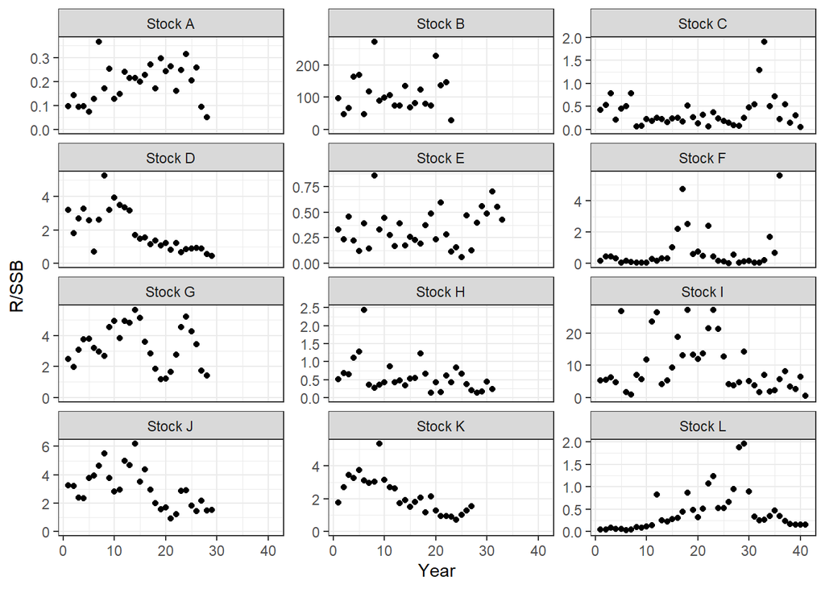

Figure 9: Annual recruits per spawning stock biomass (R/SSB) for twelve stocks.

```r
# asap.names <- list.files("asaprdats")
# nfiles <- length(asap.names)
# for (i in 1:nfiles){
#   asap <- dget(file.path("asaprdats", asap.names[i]))
#   ny <- asap$parms$nyears
#   ssb <- asap$SSB[1:(ny-1)] # drop last SSB
#   recruits <- asap$N.age[(2:ny),1] # drop first recruitment so R lagged correctly
#   RpSSB <- recruits / ssb
#   Year <- 1:length(RpSSB)
#   thisdfrl <- tibble(stock=paste("Stock", LETTERS[i]), Year=Year, RpSSB=RpSSB, Recruits=recruits, SSB=ssb)
#   if (i == 1){
#     dfrl <- thisdfrl
#   }else{
#     dfrl <- rbind(dfrl, thisdfrl)
#   }
# }
#
# write_rds(dfrl, file = "someASAPdata.RDS")

dfrl <- read_rds(file = "someASAPdata.RDS")

ggplot(dfrl, aes(x=Year, y=RpSSB)) +
  geom_point() +
  facet_wrap(~stock, scales="free_y", ncol=3) +
  ylab("R/SSB") +
  expand_limits(y = 0) +
  theme_bw()
```

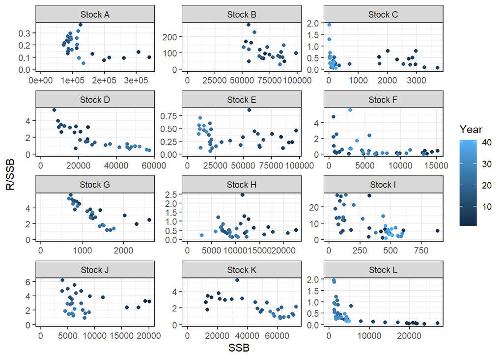

Figure 10: Recruits per spawning stock biomass (R/SSB) plotted against SSB for twelve stocks.

```r
ggplot(dfrl, aes(x=SSB, y=RpSSB, color=Year)) +
  geom_point() +
  facet_wrap(~stock, scales="free", ncol=3) +
  ylab("R/SSB") +
  expand_limits(x = 0, y = 0) +
theme_bw()
```

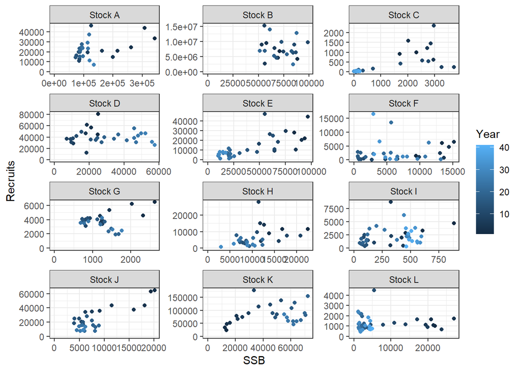

Figure 11: Standard stock-recruitment plot for twelve stocks.

```r
ggplot(dfrl, aes(x=SSB, y=Recruits, color=Year)) +
  geom_point() +
  facet_wrap(~stock, scales="free", ncol=3) +
  expand_limits(x = 0, y = 0) +
  theme_bw()
```

## How should productivity changes be estimated?

Even in the absence of a known environmental driver, it may be informative to try to fit a time-varying stock-recruitment function. For example, allowing one or more of the parameters in Equation 1 to be a time-varying random effect would allow for changes in productivity without the need for an explicit link to a covariate. Although this option is not currently available in WHAM, future work could either create this functionality or explore how to use a dummy environmental covariate to serve this purpose.

When the full state-space stock assessment with environmental covariate or time-varying stock-recruitment productivity is not possible, one could attempt to fit a single stock recruitment curve to the data (within the model if possible, see Brooks and Deroba (2015)) and examine deviations (residuals) from the stock recruitment curve as potential indicators of changes in productivity. However, stock recruitment curves are notoriously hard to estimate, and recent guidance for stock assessment models is to instead estimate recruitment as deviations from a mean value (Brooks (2024)), therefore interpretation of residuals should be done with care.

## Conclusions and recommendations

- Be careful using an R/SSB time series to detect changes in productivity because R/SSB is not expected to remain constant across SSB under commonly-used stock-recruitment functions
- Always look at R/SSB as a function of SSB and the standard stock-recruit plot when examining R/SSB time series
- Specific situations where R/SSB time series may be informative are:
  - R/SSB decreases despite large decreases in SSB
  - R/SSB increases despite large increases in SSB
  - Systematic deviations in the R/SSB vs SSB plot from the expected inverse relationship
- Future research should include
  - Use WHAM to generate situations with and without productivity changes and explore ability to detect difference using R/SSB vs time, R/SSB vs SSB, R vs SSB
  - Use WHAM to explore the ability to detect productivity changes using random effects on SR parameters
  - Develop more structured guidance of how to use (or not) R/SSB time series
  - Simulation studies of how much R/SSB time series can mislead regarding productivity changes

## Acknowledgments

Thanks to the Population Dynamics Branch for feedback on an earlier draft of this work.

## Note

- to extract all the R code from this qmd file, use the following command in the Console: knitr::purl(“RperSSB_and_productivity_changes.qmd”)

## References

Bell, R.J., Tableau, A., and Collie, J.S. 2023. Changes in the productivity of US west coast fish stocks. Fisheries Research **264**: 106712. doi:https://doi.org/10.1016/j.fishres.2023.106712.

Beverton, R.J.H., and Holt, S.J. 1957. On the dynamics of exploited fish populations. Gt Britain Fish Invest. Ser. 2 **19**: 1–533.

Brooks, E.N. 2024. Pragmatic approaches to modeling recruitment in fisheries stock assessment: A perspective. Fisheries Research **270**: 106896. doi:https://doi.org/10.1016/j.fishres.2023.106896.

Brooks, E.N., and Deroba, J.J. 2015. When “data” are not data: The pitfalls of post hoc analyses that use stock assessment model output. Canadian Journal of Fisheries and Aquatic Sciences **72**(4): 634–641. doi:10.1139/cjfas-2014-0231.

Brooks, E.N., and Legault, C.M. 2016. Retrospective forecasting — evaluating performance of stock projections for new england groundfish stocks. Canadian Journal of Fisheries and Aquatic Sciences **73**(6): 935–950. doi:10.1139/cjfas-2015-0163.

Fry, F.E.J. 1971. 1 - the effect of environmental factors on the physiology of fish. *In* Environmental relations and behavior. *Edited by* W.S. Hoar and D.J. Randall. Academic Press. pp. 1–98. doi:https://doi.org/10.1016/S1546-5098(08)60146-6.

Haines, H., Planque, B., and Buttay, L. 2024. Poor performance of regime shift detection methods in marine ecosystems. ICES Journal of Marine Science **82**(1): fsae103. doi:10.1093/icesjms/fsae103.

Hilborn, R., and Walters, C.J. 1992. Quantitative fisheries stock assessment. Springer, New York. doi:https://doi.org/10.1007/978-1-4615-3598-0.

ICES. 2025. Methods Working Group (MGWG; outputs from 2024 meeting). doi:10.17895/ices.pub.28247921.v1.

Iles, T.C., and Beverton, R.J.H. 1998. Stock, recruitment and moderating processes in flatfish. Journal of Sea Research **39**(1): 41–55. doi:https://doi.org/10.1016/S1385-1101(97)00022-1.

Legendre, P., and L., L. 2012. Numerical ecology. Elsevier, Amsterdam.

Mildenberger, T.K., Berg, C.W., Kempf, A., Rindorf, A., MacCall, A.D., and Taylor, M.H. 2025. Estimating time-varying productivity and reference points: A case of north sea demersal fish stocks. Fish and Fisheries **26**(5): 745–771. doi:https://doi.org/10.1111/faf.12910.

Miller, T.J., and Brooks, E.N. 2021. Steepness is a slippery slope. Fish and Fisheries **22**(3): 634–645. doi:https://doi.org/10.1111/faf.12534.

Pan, M., and Walden, J. 2015. Measuring productivity in a shared stock fishery: A case study of the hawaii longline fishery. Marine Policy **62**: 302–308. doi:https://doi.org/10.1016/j.marpol.2015.07.018.

Prager, H., Michael. 1994. A suite of extensions to a nonequilibrium surplus-production model. Fishery Bulletin **92**: 374–389.

Ricker, W.E. 1954. Stock and recruitment. Journal of the Fisheries Research Board of Canada **11**(5): 559–623. doi:10.1139/f54-039.

Rodionov, S.N. 2004. A sequential algorithm for testing climate regime shifts. Geophysical Research Letters **31**(9). doi:https://doi.org/10.1029/2004GL019448.

Room, A.H., Franco-Gaviria, F., and Urrego, D.H. 2020. rshift: Paleoecology and regime shift analysis. Available from https://CRAN.R-project.org/package=rshift.

Stock, B.C., and Miller, T.J. 2021. The woods hole assessment model (WHAM): A general state-space assessment framework that incorporates time- and age-varying processes via random effects and links to environmental covariates. Fisheries Research **240**: 105967. doi:https://doi.org/10.1016/j.fishres.2021.105967.

Stock, C.A., John, J.G., Rykaczewski, R.R., Asch, R.G., Cheung, W.W.L., Dunne, J.P., Friedland, K.D., Lam, V.W.Y., Sarmiento, J.L., and Watson, R.A. 2017. Reconciling fisheries catch and ocean productivity. Proceedings of the National Academy of Sciences **114**(8): E1441–E1449. doi:10.1073/pnas.1610238114.

Therneau, T., Atkinson, B., and Ripley, B. 2015. rpart: Recursive partitioning and regression trees. Available from https://CRAN.R-project.org/package=rpart.

Walters, C.J. 1987. Nonstationarity of production relationships in exploited populations. Canadian Journal of Fisheries and Aquatic Sciences **44**(S2): s156–s165. doi:10.1139/f87-319.

Wor, C., Greenberg, D.A., Holt, C.A., Connors, B., Feddern, M.L., Freshwater, C., Britten, G.L., and Mazur, M. 2025. Recommendations for estimating and detecting time-varying spawner-recruit dynamics in fish populations. Ecological Modelling **507**: 111159. doi:https://doi.org/10.1016/j.ecolmodel.2025.111159.